# W06-Reflection Essay-Introduction to Positron

Author

Saurabh Parate

Published

March 14, 2026

# 1 Essay Responses

## 1.1 **Prompt 1**

Download and Install Positron. As you watch the videos in Step 1 and Step 3, follow the activities in the video and be familiar with Positron.

**Response**  
For this assignment, I downloaded Positron from the official Posit website and installed it on my computer. After installing it, I opened Positron and explored the interface while following the videos in Step 1 and Step 3. The interface looked somewhat familiar because it resembles RStudio in many ways, but it also includes features similar to Visual Studio Code.  
One of the first things I learned was that Positron works using a **project folder or workspace**. When I opened a folder in Positron, it automatically set the working directory for the project. This makes it easier to organize files such as scripts, data, and reports in one location. I also learned how to create and run R scripts inside the editor and view the results in the console.  
The videos also introduced the main components of the Positron interface, including the **activity bar, editor, console, and session variables panel**. The activity bar allows quick access to tools such as the file explorer, search, version control, and the AI assistant. The editor is where code is written, while the console shows the output when code is executed. The session variables pane displays objects created during the session, similar to the environment pane in RStudio. By following the steps in the videos, I became familiar with how to run code, inspect data, and navigate the workspace in Positron.

## 1.2 **Prompt 2**

Based on what you learned from Step 1 and Step 3, what do you like about Positron compared with RStudio?  
**Response**  
Based on the videos and my own exploration, there are several things I like about Positron compared with RStudio. One major advantage is that Positron combines features from **RStudio and Visual Studio Code**. It maintains the familiar structure of RStudio while also providing the speed and flexibility of VS Code.  
Another feature I like is that Positron supports **both R and Python** in the same environment. This is useful because many data science projects require working with multiple programming languages. In Positron, it is easy to switch between interpreters, which makes the workflow smoother compared to using separate tools.  
I also like the interface layout. The activity bar on the left provides quick access to important tools, and the session variables, plots, and help panels appear on the right side of the screen. This layout makes it easy to see data, code, and results at the same time.  
Another feature that stood out to me is the **data explorer and data grid**, which allow users to inspect datasets in a spreadsheet-like view. This makes it easier to explore and understand data compared with viewing it only in the console.  
Overall, Positron feels more modern and flexible than RStudio while still maintaining the familiar workflow that R users are used to.

## 1.3 **Prompt 3**

In Step 4, the video demonstrates how you can use AI. Describe the various ways you can use AI inside Positron. Some are free while others are not.  
**Response**  
Step 4 introduced several AI features available in Positron. One of the main tools is Positron Assistant, which acts as an AI helper inside the IDE. This assistant can help with tasks such as explaining code, debugging errors, generating example code, and suggesting ways to analyze data.  
Another AI feature demonstrated in the video is inline code suggestions. These suggestions appear automatically while writing code and can help complete lines of code or suggest functions. This feature can save time when writing repetitive code or when trying to remember the correct syntax.  
The video also introduced Databot, which helps with exploratory data analysis. Databot can analyze a dataset and suggest possible analyses, visualizations, and summaries. This can help users quickly explore patterns in data and generate ideas for further analysis.  
Some AI tools inside Positron are free, while others require an account or subscription. For example, GitHub Copilot offers free access for students through the GitHub Education program, while other AI providers may require paid access or API keys depending on the service used.  
Overall, AI in Positron helps automate repetitive tasks, provide coding suggestions, and support data exploration while still allowing the user to control and verify the results.

## 1.4 **Prompt 4**

Which AI tools have you installed or set up? Which AI tools did you find beneficial for you?  
**Response**  
One of the main AI tools I explored is **GitHub Copilot**, which can be integrated with Positron. GitHub Copilot provides real-time coding suggestions and can generate code based on the context of the file. This makes it easier to write scripts more quickly and reduces the time spent searching for examples online.  
Among these tools, GitHub Copilot felt the most useful for everyday coding tasks. It can quickly suggest code for creating data frames, writing loops, or generating plots. The Positron Assistant is also beneficial because it helps explain code and assist with debugging when errors occur.

## 1.5 **Prompt 5**

Apply for GitHub Copilot education account and take a screenshot showing you were accepted. Play with it and do you find it helpful or distracting? Please elaborate.

**Response**  
I connected my GitHub account with my **CPP.edu student account**, which automatically gave me access to the **GitHub Education program**. Because of this, GitHub Copilot was already available for me to use inside Positron without needing an additional subscription.  
After signing into GitHub within Positron, Copilot started providing **inline code suggestions** while I was writing code. This feature automatically suggests lines of code based on the context of what I am typing. I found this helpful because it speeds up coding and helps when I forget the exact syntax for certain functions or commands.  
Since Copilot is integrated directly into Positron, it works smoothly with the editor and allows me to accept suggestions quickly while writing scripts. Overall, I found GitHub Copilot to be helpful rather than distracting because it improves productivity and assists with coding tasks while still allowing me to review and modify the suggested code.  
Below is a screenshot showing that my GitHub account is connected.

[figure not shown]

**Example**:

```
$students
# A tibble: 120 × 2
   student_id score
   <chr>      <dbl>
 1 S001          68
 2 S002          72
 3 S003          94
 4 S004          76
 5 S005          77
 6 S006          96
 7 S007          81
 8 S008          60
 9 S009          67
10 S010          70
# ℹ 110 more rows

$histogram
```

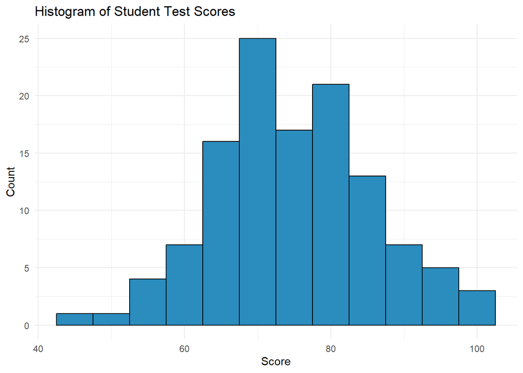

```r
set.seed(123)
n <- 120

students <- tibble::tibble(
  student_id = sprintf("S%03d", seq_len(n)),
  score = pmin(pmax(round(rnorm(n, mean = 75, sd = 12)), 0), 100)
)

hist_plot <- ggplot2::ggplot(students, ggplot2::aes(x = score)) +
  ggplot2::geom_histogram(binwidth = 5, color = "black", fill = "#2b8cbe") +
  ggplot2::labs(title = "Histogram of Student Test Scores", x = "Score", y = "Count") +
  ggplot2::theme_minimal()

list(students = students, histogram = hist_plot)
```

## 1.6 **Prompt 6**

Publish this report to GitHub Pages and provide a URL to the GitHub Pages for the report.  
Response  
After completing this Quarto report, I published the rendered HTML file to **GitHub Pages**. GitHub Pages allows users to host a website directly from a GitHub repository. While the repository stores the project files, GitHub Pages publishes the rendered HTML as a web page that can be accessed through a browser.  
Publishing the report this way allows the assignment to be shared as a website rather than just a local file. This demonstrates how Quarto can be used to produce professional reports that are easy to share online.  
GitHub Pages URL:  
https://saurabhparate1619.github.io/IBM6540/w06